# Lab 08 - Dashboard Layout

#### [DS4PS](https://ds4ps.github.io/course_website/)

In this lab you will practice creating a [dashboard layout](https://rmarkdown.rstudio.com/flexdashboard/layouts.html) in R. You will create a 3-window dashboard and a 4-window dashboard (examples below, though you can select different designs).

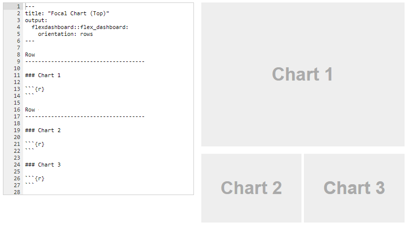

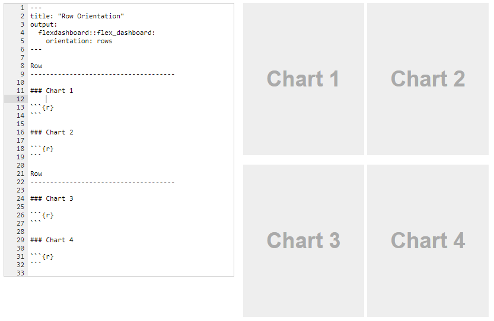

You will need the following packages:

```r
install.packages( "flexdashboard" )  # dashboards in r
install.packages( "DT" )             # data tables
```

# Data

We are using the same dataset as last week. The **Teams** dataset in the Lahman package contains season statistics for each baseball team from the late 1800s onward.

```r
library( Lahman )
data( Teams )
```

## Data Tables

We want the user to be able to explore the data in the graphics, so we will embed a data table in the dashboard.

Note that previously we have added a static table to our report using some functions that format the printed table, usually with the pander() function from the **pander** package:

```r
# library( pander )
pander( head( Teams[c("name","yearID","SO","H","HR","G") ] ) )
```

| name | yearID | SO | H | HR | G |
| --- | --- | --- | --- | --- | --- |
| Boston Red Stockings | 1871 | 19 | 426 | 3 | 31 |
| Chicago White Stockings | 1871 | 22 | 323 | 10 | 28 |
| Cleveland Forest Citys | 1871 | 25 | 328 | 7 | 29 |
| Fort Wayne Kekiongas | 1871 | 9 | 178 | 2 | 19 |
| New York Mutuals | 1871 | 15 | 403 | 1 | 33 |
| Philadelphia Athletics | 1871 | 23 | 410 | 9 | 28 |

We obviously can’t print the entire 2,800+ row table. So instead, we will use the datatable() function from the **DT** package, which creates a table that can be searched, filtered, and sorted.

```r
# library( DT )
datatable( Teams[c("name","yearID","SO","H","HR","G") ],
           filter='top', rownames = FALSE,
           options=list( pageLength=6, autoWidth=TRUE) )
```

| name | yearID | SO | H | HR | G |
| --- | --- | --- | --- | --- | --- |
| Boston Red Stockings | 1871 | 19 | 426 | 3 | 31 |
| Chicago White Stockings | 1871 | 22 | 323 | 10 | 28 |
| Cleveland Forest Citys | 1871 | 25 | 328 | 7 | 29 |
| Fort Wayne Kekiongas | 1871 | 9 | 178 | 2 | 19 |
| New York Mutuals | 1871 | 15 | 403 | 1 | 33 |
| Philadelphia Athletics | 1871 | 23 | 410 | 9 | 28 |
| Rockford Forest Citys | 1871 | 30 | 274 | 3 | 25 |
| Troy Haymakers | 1871 | 19 | 384 | 6 | 29 |
| Washington Olympics | 1871 | 13 | 375 | 6 | 32 |
| Baltimore Canaries | 1872 | 28 | 747 | 14 | 58 |

[output cut: 2825 more lines]

# Graphics

You will practice creating a dashboard using graphics that report season statistics standardized by the number of games that were played. You can use these three statistics, or calculate any of your own from the Teams dataset.

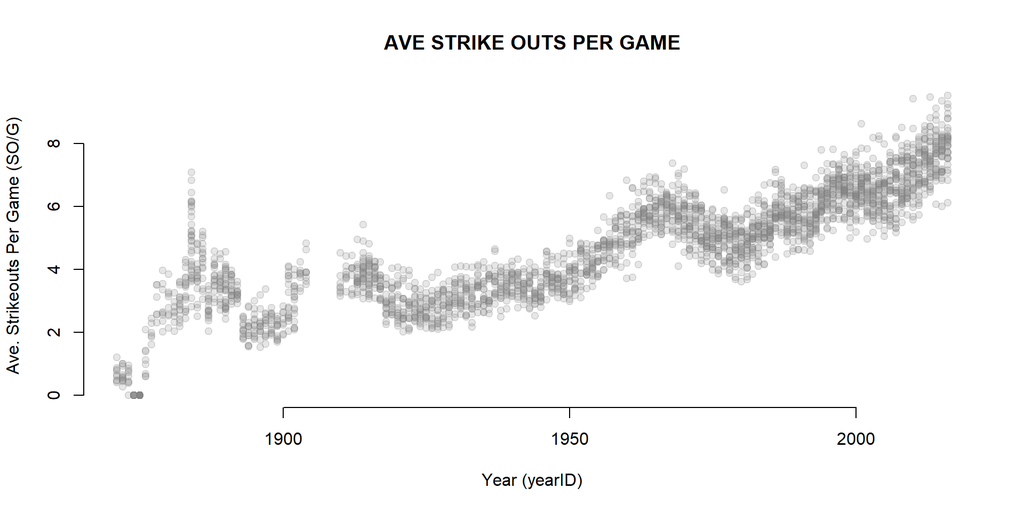

```r
plot( Teams$yearID, Teams$SO/Teams$G, pch=19, col=gray(0.5,0.2), bty="n",
      ylab="Ave. Strikeouts Per Game (SO/G)",
      xlab="Year (yearID)", main="AVE STRIKE OUTS PER GAME" )
```

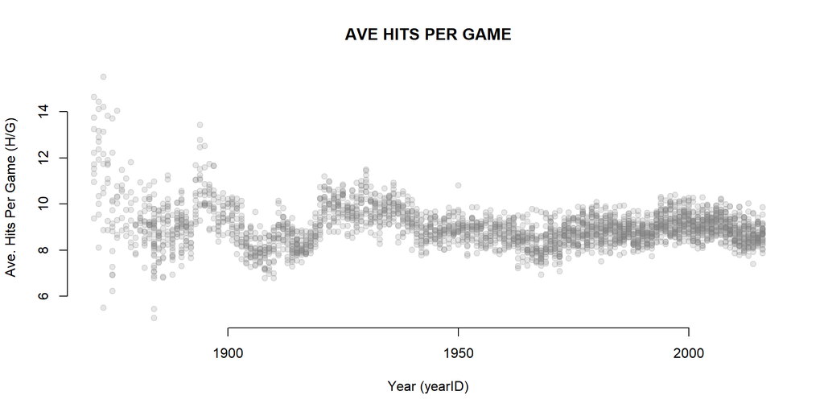

```r
plot( Teams$yearID, Teams$H/Teams$G, pch=19, col=gray(0.5,0.2), bty="n",
      ylab="Ave. Hits Per Game (H/G)", xlab="Year (yearID)", main="AVE HITS PER GAME" )
```

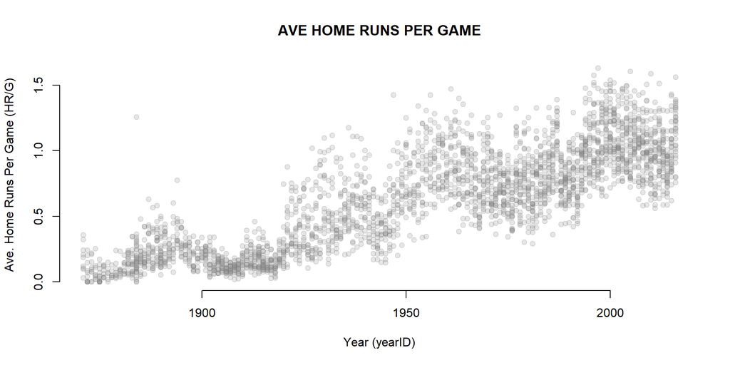

```r
plot( Teams$yearID, Teams$HR/Teams$G, pch=19, col=gray(0.5,0.2), bty="n",
      ylab="Ave. Home Runs Per Game (HR/G)",
      xlab="Year (yearID)", main="AVE HOME RUNS PER GAME" )
```

# Lab Instructions

**PART 1:**

- Create a flexdashboard layout with **THREE** windows.
- Add **two** graphics and **one** datatable to the dashboard.
- Save this file as **Lab-08-LastName-V1.Rmd**.

**PART 2:**

- Create a flexdashboard layout with **FOUR** windows.
- Add **three** graphics and **one** datatable to the dashboard.
- Save this file as **Lab-08-LastName-V2.Rmd**.

**INSTRUCTIONS**

- Select layout styles from the [flexdashboard layout gallery](https://rmarkdown.rstudio.com/flexdashboard/layouts.html). You are free to use whatever styles you want, including those with tabs, as long as they have the correct number of windows.
- You can use the graphics above, or calculate your own statistics from data in the Teams dataset.
- You will NOT use shiny for this lab.
- Hide your code using the code chunk “echo=F” option.
- Add year trend lines to your graphs, and whatever aesthetics you want.
- Follow the instructions below for creating your data table.

**Data Table**

Use the datatable() function in the DT package to add the table to your dashboard. These options are fine, but you are free to customize your table using [DT options](https://rstudio.github.io/DT/) from their website.

```r
datatable( Teams[c("name","yearID","SO","H","HR","G") ],
           filter='top', rownames = FALSE,
           options=list( pageLength=6, autoWidth=TRUE) )
```

Your table will look similar to the one above. HOWEVER, your data table should report the statistics that are reported on your graphs, not the raw statistics that are reported here. For example, in the lab last week we used “average strikeouts per game” (SOPG) instead of “strike outs” (SO).

You need to create a new dataframe that ONLY reports team name (“name”), year of season (“yearID”), games played (“G”), and the statistics from your graphs.

Use dplyr functions like mutate() to create your statistics and add them back to your dataset, and select() to keep only relevant variables before printing your table.

**OPTIONAL**

These options are not required for the lab, but you will find them useful in the future. You are welcome to include them in your dashboard if you would like to experiment.

**Responsive Graphics:**

When you are writing a typical report the size of graphics will be predictable because they are embedded in reports that are typically printed on 8.5 x 11 inch pages or rendered as PDFs.

When creating dashboards predicting the size of graphics can be a lot more challenging. Your dashboard has a dynamic layout that scales with the size of the web browser, but that will depend upon the size of the screen, which varies greatly between mobile phones, tablets, laptops, and desktops.

As a result, it is much better to use “responsive” graphics, meaning those that do not have a set size or aspect ratio. These are typically HTML or javascript objects embedded in web pages. Fortunately R has some packages that will convert static R graphs to these sorts of objects to make them responsive.

We have not yet introduced **ggplot2**, but it is one of the most powerful and popular graphing packages in R. It was created by the same team that created **dplyr** and R Studio. In this example, we create a baseball graph in R, then convert it to HTML using the plotly package.

```r
library( ggplot2 )
library( plotly )

Teams <- mutate( Teams, HG=H/G )

league <-
  Teams %>%
  group_by( yearID ) %>%
  summarize( ave.hits =mean( H / G , na.rm=T ) )

p <- ggplot( data=Teams, aes( x=yearID, y=HG  ) ) +
     geom_point( col="gray", alpha=0.3, size=2, aes( text=name ) ) +
     geom_line( data=league, aes(x=yearID,y=ave.hits), col="blue" ) +
     ggtitle( "Ave Hits Per Game" ) +
     theme_bw()

ggplotly( p )
```

[output not shown]

**Export Buttons:**

DT tables have a lot of powerful features. One is the ability to add export functions so that the user can save the data to their own machine for use later. When you have the filter feature and the export feature active together, it allows the user to define a specific dataset before exporting.

You can try it out using this code.

```r
library( DT )

sub.t <- Teams[ c("name","yearID","SO","H","HR","G") ]

show.these.buttons <- c( 'copy', 'csv', 'excel', 'pdf', 'print' )

datatable(  sub.t,
           filter='bottom', rownames=FALSE,
           #options=list( pageLength=5, autoWidth=TRUE ),
           fillContainer=TRUE,
           style="bootstrap",
           class='table-condensed table-striped',
           extensions = 'Buttons',
           options=list( dom='Bfrtip',
                         buttons=show.these.buttons  )) %>%

  formatStyle( "name", "white-space"="nowrap" )
```

# Submission Instructions

You will submit your two RMD files. No HTML files are needed.

- **Lab-08-LastName-V1.Rmd**
- **Lab-08-LastName-V2.Rmd**

Login to Canvas at http://canvas.asu.edu and navigate to the assignments tab in the course repository. Upload your RMD files to the appropriate lab submission link.